# Deep Learning — Assignment 1 — Score sheet

First assignment for the 2023 Deep Learning course (NWI-IMC070) of the Radboud University.

Please enter your names and group number.**Names:**

**Group:**

**Instructions:**

- Fill in your names and the name of your group.
- Answer the questions and complete the code where necessary.
- Keep your answers brief, one or two sentences is usually enough.
- Re-run the whole notebook before you submit your work.
- Save the notebook as a PDF and submit that in Brightspace together with the `.ipynb` notebook file.
- The easiest way to make a PDF of your notebook is via File > Print Preview and then use your browser's print option to print to PDF.

## Objectives

In this assignment you will

1. Experiment with gradient descent optimization;
2. Derive and implement gradients for binary cross-entropy loss, the sigmoid function and a linear layer;
3. Test your gradient implementations with the finite difference method;
4. Use these components to implement and train a simple neural network.

```python
%matplotlib inline
import numpy as np
import scipy.optimize
import sklearn.datasets
import matplotlib.pyplot as plt

np.set_printoptions(suppress=True, precision=6, linewidth=200)
plt.style.use('ggplot')
```

## 1.1 Gradient descent optimization (6 points)

Consider the following function with two parameters and its derivatives: \begin{align} f(x, y) &= x^2 + y^2 + x (y + 2) + \cos(3x) \\ \frac{\partial f}{\partial x} &= 2x - 3\sin(3x) + y + 2 \\ \frac{\partial f}{\partial y} &= x + 2y \\ \end{align}

```python
def f(x, y):
    return x ** 2 + y ** 2 + x * (y + 2) + np.cos(3 * x)
def grad_x_f(x, y):
    return 2 * x - 3 * np.sin(3 * x) + y + 2
def grad_y_f(x, y):
    return x + 2 * y
```

A plot of the function shows that it has multiple local minima:

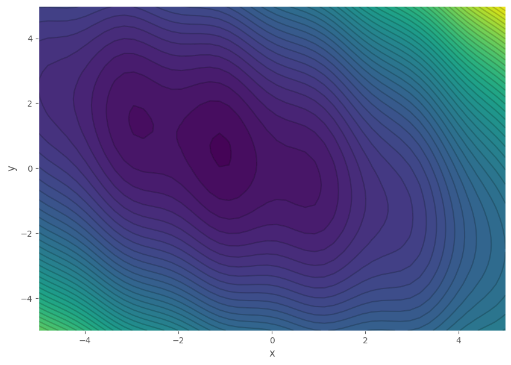

```python
def plot_f_contours():
    xx, yy = np.meshgrid(np.linspace(-5, 5), np.linspace(-5, 5))
    zz = f(xx, yy)
    plt.contourf(xx, yy, zz, 50)
    plt.contour(xx, yy, zz, 50, alpha=0.2, colors='black', linestyles='solid')
    plt.xlabel('x')
    plt.ylabel('y')

plt.figure(figsize=(10, 7))
plot_f_contours()
```

### Implement gradient descent

We would like to find the minimum of this function using gradient descent.

**1.1 a Add comment(a) Implement the gradient descent updates for $x$ and $y$ in the function below: (1 point)**

*Grading:*

- 1 point for a fully correct implementation.
- 0 points if the sign is incorrect (if you are doing gradient *ascent*)
- 0 points if not multiplying by `step_size`

```python
def optimize_f(x, y, step_size, steps):
    # keep track of the parameters we tried so far
    x_hist, y_hist = [x], [y]

    # run gradient descent for the number of steps
    for step in range(steps):
        # compute the gradients at the current point
        dx = grad_x_f(x, y)
        dy = grad_y_f(x, y)

        # apply the gradient descent updates to x and y
        ### BEGIN ANSWER
        x = x - step_size * dx
        y = y - step_size * dy
        ### END ANSWER

        # store the new parameters
        x_hist.append(x)
        y_hist.append(y)

    return x, y, f(x, y), x_hist, y_hist
```

```python
# The following assert statements check that your implementation behaves sensibly
# Use it to get a hint only if you are stuck.
assert optimize_f(3, 2, 0.1, 1)[0] != 3, "Hint: you are not changing `x`"
assert optimize_f(3, 2, 0.1, 1)[2] < f(3, 2), "Hint: the function value is increasing, you should be minimizing it, not maximizing."
assert abs(optimize_f(3, 2, 0.1, 1)[0] - 3) < 1, "Hint: you are probably taking steps that are too large."
```

### Tune the parameters

We will now try if our optimization method works.

Use this helper function to plot the results:

```python
# helper function that plots the results of the gradient descent optimization
def plot_gradient_descent_results(x, y, val, x_hist, y_hist):
    # plot the path on the contour plot
    plt.figure(figsize=(20, 7))
    plt.subplot(1, 2, 1)
    plot_f_contours()
    plt.plot(x_hist, y_hist, '.-')

    # plot the learning curve
    plt.subplot(1, 2, 2)
    plt.plot(f(np.array(x_hist), np.array(y_hist)), '.r-')
    plt.title('Minimum value: %f' % f(x_hist[-1], y_hist[-1]))
```

**(b) Run the gradient descent optimization with the following initial settings:**

`x=3, y=2, step_size=0.1, steps=10`

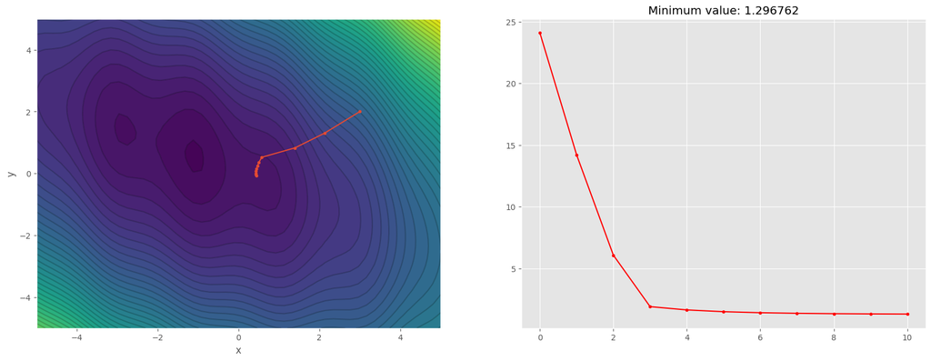

```python
results = optimize_f(x=3, y=2, step_size=0.1, steps=10)
plot_gradient_descent_results(*results)
```

**1.1 c Add comment(c) Does it find the minimum of the function? What happens? (1 point)**

Answer: No, the optimization ends in a local minimum, where it gets stuck.

*Grading:*

- 1 point for correctly observing that optimization ends in a local minimum.
- 0.5 point for answering "no" without mentioning that you end up in a local minimum or not in the global minimum.
- 0 points if you answer "yes".

**(d) Try a few different values for the `step_size` and the number of `steps` to get close to the optimal solution:**

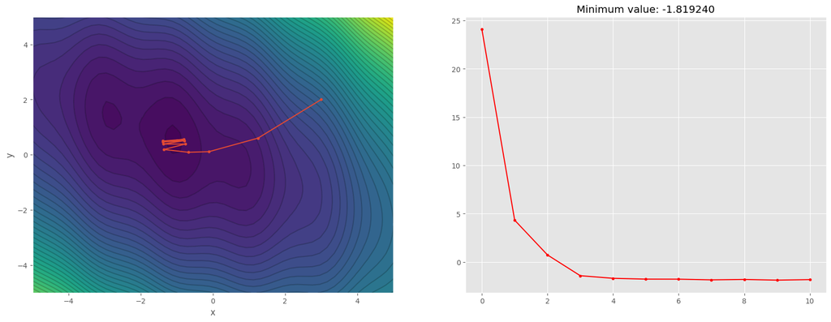

```python
### BEGIN ANSWER
results = optimize_f(x=3, y=2, step_size=0.2, steps=10)
### END ANSWER
plot_gradient_descent_results(*results)
```

**1.1 e Add comment(e) What happens if you set the step size too small? And what if it is too large? (1 point)**

The step size for this problem is quite sensitive. It should be large enough to escape the local optimum. With *too small* step sizes you get stuck there.

But if you set the step size it *too large* it will never converge. In that case the optimization moves around the global minimum, but never quite reaches it.

*Grading:*

- 0.5 point for "too small"
- 0.5 point for "too large"

**1.1 f Add comment(f) Were you able to find a step size that reached the global optimum? If not, why not? (1 point)**

Yes, or at least, you can get close.

With very careful tuning you might find a combination that gives a better result than we have here.

*Grading:*

- 1 point for a correct analysis that matches the result at 1(d).
- It is ok to argue that the optimum is never reached exactly, but that you can get close.

### Implement a decreasing step size

You might get better results if you use a step size that is large at the beginning, but slowly decreases during the optimization.

Try the following scheme to compute the step size $\eta_t$ in step $t$, given a decay parameter $d$: \begin{align} \eta_t = \eta_0 d^t \end{align}

**1.1 g Add comment(g) Update your optimization function to use this step size schedule: (1 point)**

*Grading:*

- 1 point for a fully correct implementation.
- You can either use `decay ** step` in the update steps, or multiply `step_size` by `decay` in every iteration.

```python
def optimize_f(x, y, step_size, steps, decay=1.0):
    # keep track of the parameters we tried so far
    x_hist, y_hist = [x], [y]

    # run gradient descent for the number of steps
    for step in range(steps):
        # compute the gradients at this point
        dx = grad_x_f(x, y)
        dy = grad_y_f(x, y)

        # apply the gradient descent updates to x and y
        ### BEGIN ANSWER
        x = x - dx * step_size * decay ** step
        y = y - dy * step_size * decay ** step
        ### END ANSWER

        # store the new parameters
        x_hist.append(x)
        y_hist.append(y)

    return x, y, f(x, y), x_hist, y_hist
```

```python
# The following assert statement checks that your implementation behaves sensibly
_trace = optimize_f(0.123, 0.456, 0.01, 2, 0.1)[3]
assert abs(_trace[1] - _trace[0]) > 5 * abs(_trace[2] - _trace[1]), "Hint: step size should be decreasing"
del _trace
```

**1.1 h Add comment(h) Tune the `step_sizes`, `steps` and `decay` parameters to get closer to the global minimum: (1 point)**

*Grading:*

- 1 point if you get reasonably close to the global minimum.
- The values below give one possible solution. The answer should have `decay < 1` and initial `step_size > 0.1`.

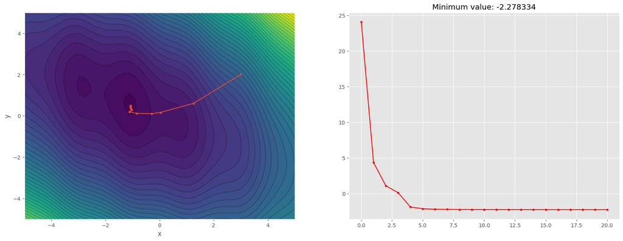

```python
### BEGIN ANSWER
results = optimize_f(x=3, y=2, step_size=0.2, steps=20, decay=0.9)
plot_gradient_descent_results(*results)
### END ANSWER
```

```python
assert results[2] < -2, "Hint: get closer to the optimum"
```

We will now look at some more complex functions that we can try to optimize.

## 1.2 Neural network components (16 points)

In this assignment, we will implement a simple neural network from scratch. We need four components:

1. A sigmoid activation function,
2. A ReLU activation function,
3. A binary cross-entropy loss function,
4. A linear layer.

For each component, we will implement the forward pass, the backward pass, and the gradient descent update.

### Sigmoid non-linearity

The sigmoid function is defined as:

\begin{align} \sigma(x) &= \frac{1}{1 + e^{-x}} \\ \end{align}

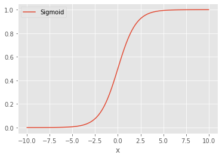

**1.2 a Add comment(a) Give the derivative of the sigmoid function: (1 point)**

Possible answers are: \begin{align} \frac{\partial \sigma(x)}{\partial x} &= \frac{e^x}{(1 + e^x)^2} = \frac{e^{-x}}{(1 + e^{-x})^2} = \sigma(x)\sigma(-x) = \sigma(x)(1 - \sigma(x)) \end{align}

*Grading:*

- There are multiple ways to write the answer.
- 1 point for a correct definition that is not overly complicated and passes the test at (c) below.

**1.2 b Add comment(b) Implement the sigmoid and its gradient in the functions `sigmoid(x)` and `sigmoid_grad(x)`: (2 points)**

*Grading:*

- 1 point for each correctly implemented function.

```python
def sigmoid(x):
    ### BEGIN ANSWER
    return 1 / (1 + np.exp(-x))
    ### END ANSWER

def sigmoid_grad(x):
    ### BEGIN ANSWER
    return np.exp(x) / (1 + np.exp(x)) ** 2
    ### END ANSWER

# try with a random input
rng = np.random.default_rng(12345)
x = rng.uniform(-10, 10, size=5)
print('x:', x)
print('sigmoid(x):', sigmoid(x))
print('sigmoid_grad(x):', sigmoid_grad(x))
```

```
x: [-5.45328  -3.664833  5.947309  3.525093 -2.177809]
sigmoid(x): [0.004264 0.024969 0.997394 0.971393 0.101761]
sigmoid_grad(x): [0.004246 0.024346 0.002599 0.027788 0.091406]
```

To check that the gradient implementation is correct, we can compute the numerical derivative using the [finite difference](https://en.wikipedia.org/wiki/Finite_difference) method. From [Chapter 11.5 of the Deep Learning book](http://www.deeplearningbook.org/contents/guidelines.html):

> Because

\begin{align} f'(x) = \lim_{\epsilon \rightarrow 0} \frac{f(x + \epsilon) - f(x)}{ \epsilon}, \end{align} we can approximate the derivative by using a small, finite $\epsilon$: \begin{align} f'(x) \approx \frac{f(x + \epsilon) - f(x)}{\epsilon}. \end{align} We can improve the accuracy of the approximation by using the centered difference: \begin{align} f'(x) \approx \frac{f(x + \frac{1}{2} \epsilon) - f(x - \frac{1}{2} \epsilon)}{\epsilon}. \end{align} The perturbation size $\epsilon$ must be large enough to ensure that the perturbation is not rounded down too much by ﬁnite-precision numerical computations.

**1.2 c Add comment(c) Use the central difference method to check your implementation of the sigmoid gradient. Compute the numerical gradient and check that it is close to the symbolic gradient computed by your implementation: (1 point)**

*Grading:*

- 1 point for a correct implementation of the numerical gradient.
- 0.5 points for using a finite difference method other than the central difference method.
- If your numerical gradient does not match the symbolic gradient, the implementation of the sigmoid may be incorrect. In that case, subtract points in question (a).

```python
# start with some random inputs
rng = np.random.default_rng(12345)
x = rng.uniform(-2, 2, size=5)

# compute the symbolic gradient
print('Symbolic ', sigmoid_grad(x))

### BEGIN ANSWER
# compute the numerical gradient
eps = 0.000001 # set epsilon to a small value
print('Numerical', (sigmoid(x + eps / 2) - sigmoid(x - eps / 2)) / eps)

# Or: use a helper function
def numerical_gradient(f, x, eps=0.000001):
    return (f(x + eps / 2) - f(x - eps / 2)) / eps
### END ANSWER
```

```
Symbolic  [0.188245 0.219215 0.178901 0.221338 0.238508]
Numerical [0.188245 0.219215 0.178901 0.221338 0.238508]
```

**1.2 d Add comment(d) Is the gradient computed with finite differences exactly the same as the analytic answer? Why (not)? (1 point)**

Answer:

It is almost the same, but not not exactly. The numerical gradient is a finite approximation that comes close to the analytical gradient if eps is small enough.

*Grading:*

- 1 point for a correct answer that mentions the approximation.
- Note: Answering "yes" is wrong, even if the numbers look the same rounded to 6 decimal places

**If there is a big difference between the two gradients, please try to make this as small as possible before you continue.**

### Rectified linear units (ReLU)

The rectified linear unit is defined as: \begin{align} f(x) = \max(0, x) \end{align}

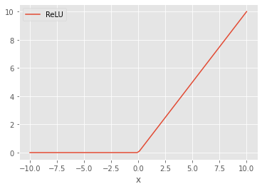

**1.2 e Add comment(e) Give the derivative of the ReLU function: (1 point)**

Note: this gradient is not well-defined everywhere, but make a sensible choice for all values of $x$.

\begin{align} \frac{\partial f(x)}{\partial x} &= \left\{ \begin{array}{ll} 1 & \text{ if } x > 0 \\ 0 & \text{ otherwise } \end{array} \right. \end{align}

*Grading:*

- 1 point for the correct definition.
- The exact notation is not important, as long as it is clear that there is a case distinction.
- Technically, for $x=0$ any value between 0 and 1 gives a valid *subgradient*.
- So, both $x > 0$ and $x \ge 0$ are acceptable in the condition.

**1.2 f Add comment(f) Implement the ReLU function and its gradient in the functions `relu(x)` and `relu_grad(x)`. Use the finite difference method to check that the gradient is correct: (2 points)**

*Grading:*

- 1 point for each correctly implemented function
- -1 point (so max 1 point in total) if not comparing the numerical and symbolic gradient.

```python
def relu(x):
    ### BEGIN ANSWER
    return np.maximum(0, x)
    ### END ANSWER

def relu_grad(x):
    ### BEGIN ANSWER
    # TODO: implement the gradient of the relu function
    return (x > 0).astype(x.dtype)
    ### END ANSWER

# try with a random input
rng = np.random.default_rng(12345)
x = rng.uniform(-10, 10, size=5)
print('x:', x)
print('relu(x):', relu(x))
print('relu_grad(x):', relu_grad(x))
print()

### BEGIN ANSWER
# compute the symbolic gradient
print('Symbolic ', relu_grad(x))
# compute the numerical gradient
print('Numerical', numerical_gradient(relu, x))
### END ANSWER
```

```
x: [-5.45328  -3.664833  5.947309  3.525093 -2.177809]
relu(x): [0.       0.       5.947309 3.525093 0.      ]
relu_grad(x): [0. 0. 1. 1. 0.]

Symbolic  [0. 0. 1. 1. 0.]
Numerical [0. 0. 1. 1. 0.]
```

### Comparing sigmoid and ReLU

The sigmoid and ReLU activation functions have slightly different characteristics.

**(g) Run the code below to plot the sigmoid and ReLU activation functions and their gradients:**

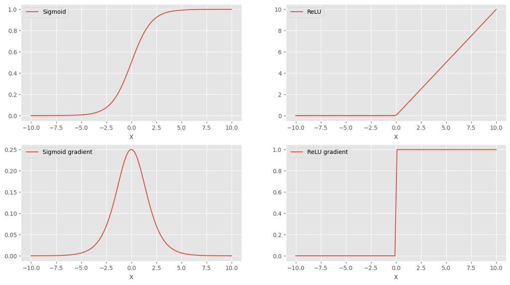

```python
x = np.linspace(-10, 10, 100)

plt.figure(figsize=(15, 8))

plt.subplot(2, 2, 1)
plt.plot(x, sigmoid(x), label='Sigmoid')
plt.xlabel('x')
plt.legend(loc='upper left')

plt.subplot(2, 2, 2)
plt.plot(x, relu(x), label='ReLU')
plt.xlabel('x')
plt.legend(loc='upper left')

plt.subplot(2, 2, 3)
plt.plot(x, sigmoid_grad(x), label='Sigmoid gradient')
plt.xlabel('x')
plt.legend(loc='upper left')

plt.subplot(2, 2, 4)
plt.plot(x, relu_grad(x), label='ReLU gradient')
plt.xlabel('x')
plt.legend(loc='upper left');
```

**1.2 h Add comment(h) Which activation function would you recommend for a network that outputs probabilities, i.e., outputs $\in [0, 1]$? Why? (1 point)**

Answer: A sigmoid function, because its output is always between 0 and 1. A ReLU can give outputs outside this range.

*Grading:*

- 1 point for a correct answer and argumentation.
- 0.5 point if missing argumentation.

**1.2 i Add comment(i) Compare the gradients for sigmoid and ReLU. What are the advantages and disadvantages of each activation function in terms of their gradient? (1 point)**

Answer:

*Grading:*

- Answer should include one advantage of sigmoid (smoothness, never 0) and one of ReLU (constant)
- 1 point for a correct answer and argumentation.
- 0.5 points if only one advantage or one disadvantage is given.

### Binary cross-entropy loss

We will use the binary cross-entropy loss to train our network. This loss function is useful for binary classification.

The binary cross-entropy (BCE) is a function of the ground truth label $y \in \{0, 1\}$ and the predicted label $\hat{y} \in [0, 1]$:

\begin{align} \mathcal{L} &= -(y \log{\hat{y}} + (1-y) \log(1-\hat{y})) \\ \end{align}

To minimize the BCE loss with gradient descent, we need to compute the gradient with respect to the prediction $\hat{y}$.

**1.2 j Add comment(j) Derive the gradient for the BCE loss: (1 point)**

\begin{align} \frac{\partial \mathcal{L}}{\partial \hat{y}} = -\frac{y}{\hat{y}} + \frac{1-y}{1-\hat{y}} = \frac{\hat{y} - y}{\hat{y} - \hat{y}^2} \end{align}

*Grading:*

- 1 point for any correct definition.
- The answer model gives two equivalent definitions.

**1.2 k Add comment(k) Implement `bce_loss(y, y_hat)` and `bce_loss_grad(y, y_hat)` and use the finite difference method to check that the gradient is correct: (3 points)**

*Grading:*

- 1 point for each correctly implemented function, and 1 point for a correct application of the numerical gradient.
- The numerical gradient should be very close to the exact gradient.

```python
def bce_loss(y, y_hat):
    ### BEGIN ANSWER
    return -(y * np.log(y_hat) + (1 - y) * np.log(1 - y_hat))
    ### END ANSWER

def bce_loss_grad(y, y_hat):
    ### BEGIN ANSWER
    return (y_hat - y) / (y_hat - y_hat ** 2)
    ### END ANSWER

# try with some random inputs
rng = np.random.default_rng(12345)
y = rng.integers(2, size=5)
y_hat = rng.uniform(0, 1, size=5)
print('y:', y)
print('y_hat:', y_hat)
print('bceloss(y, y_hat):', bce_loss(y, y_hat))
print()

### BEGIN ANSWER
# set epsilon to a small value
eps = 0.00001

# compute the symbolic gradient
print('Symbolic ', bce_loss_grad(y, y_hat))
# compute the numerical gradient
print('Numerical', (bce_loss(y, y_hat + eps / 2) - bce_loss(y, y_hat - eps / 2)) / eps)
### END ANSWER
```

```
y: [1 0 1 0 0]
y_hat: [0.676255 0.39111  0.332814 0.598309 0.186734]
bceloss(y, y_hat): [0.391186 0.496117 1.100172 0.912072 0.206697]

Symbolic  [-1.478733  1.642332 -3.004682  2.489474  1.22961 ]
Numerical [-1.478733  1.642332 -3.004682  2.489474  1.22961 ]
```

### Linear layer

Finally, we need to compute the gradients for the linear layer in our network.

Define a linear model $\mathbf{y} = \mathbf{x} \mathbf{W} + \mathbf{b}$, where

- $\mathbf{x}$ is an input vector of shape $N$,
- $\mathbf{W}$ is a weight matrix of shape $N \times M$,
- $\mathbf{b}$ is a bias vector of shape $M$,
- $\mathbf{y}$ is the output vector of shape $M$.

**1.2 l Add comment(l) Derive the gradients for $\mathbf{y}$ with respect to the input $\mathbf{x}$ and the parameters $\mathbf{W}$ and $\mathbf{b}$: (1 point)**

*Hint: If you have trouble computing this in matrix notation directly, try to do the computation with scalars, writing the linear model as* \begin{align} y_j = \sum_{i=1}^{N} x_i W_{ij} + b_j \end{align} where $j$ ranges from $1$ to $M$.

Answer: With indices we have derivatives \begin{align} \frac{\partial y_j}{\partial x_i} &= W_{ij} & \frac{\partial y_j}{\partial W_{ik}} &= \begin{cases}x_i & \text{if $j=k$} \\ 0 & \text{otherwise}\end{cases} & \frac{\partial y_j}{\partial b_k} &= \begin{cases}1 & \text{if $j=k$} \\ 0 & \text{otherwise}\end{cases} \\ \end{align} In matrix notation (note: we are abusing notation a bit here in the $\partial \mathbf{y}/\partial \mathbf{W}$ case, since the result is actually a rank 3 tensor) \begin{align} \frac{\partial \mathbf{y}}{\partial \mathbf{x}} &= \mathbf{W}^T & \frac{\partial \mathbf{y}}{\partial \mathbf{W}} &= \mathbf{x} & \frac{\partial \mathbf{y}}{\partial \mathbf{b}} &= I \\ \end{align}

*Grading:*

- 1 point for the correct definitions.
- It is acceptable if the answers are in the wrong shape (e.g. missing a transpose).
- For the gradient wrt. $b$, 1 and I are both acceptable answers.

**1.2 m Add comment(m) Given the gradient $\nabla_\mathbf{y} \mathcal{L}$ for the loss w.r.t. $\mathbf{y}$, use the chain rule to derive the gradients for the loss w.r.t. $\mathbf{x}$, $\mathbf{W}$ and $\mathbf{b}$: (1 point)**

Answer: \begin{align} \nabla_\mathbf{x} \mathcal{L} &= \nabla_\mathbf{y} \mathcal{L} \; \mathbf{W}^T \\ \nabla_\mathbf{W} \mathcal{L} &= x^T \nabla_\mathbf{y} \mathcal{L} \\ \nabla_\mathbf{b} \mathcal{L} &= \nabla_\mathbf{y} \mathcal{L} \end{align}

*Grading:*

- 1 point for the correct definitions.
- It is acceptable if some of the matrix multiplications are in the wrong order or shape (e.g., missing a transpose), but you should at least give the correct components.

## 1.3 Implement a one-layer model (2 points)

We can now implement a simple one-layer model with a sigmoid activation:

1. Given an input vector $\mathbf{x}$, weight vector $\mathbf{w}$ and bias $b$, compute the output $\hat{y}$:

\begin{align} h = \mathbf{x} \mathbf{w}^T + b \\ \hat{y} = \sigma(h) \\ \end{align}

2. Compute the BCE loss comparing the prediction $\hat{y}$ with the ground-truth label $y$.
3. Compute the gradient for the BCE loss and back-propagate this to get $\nabla_\mathbf{x} \mathcal{L}$, the gradient of $\mathcal{L}$ w.r.t. $\mathbf{x}$.

Hint: in numpy inner product and matrix multiplication is denoted as `np.dot(A, B)` or as `A @ B`.

**1.3 a Add comment(a) Complete the implementation below: (2 points)**

*Grading:*

- 1 point for a correct implementation of the forward pass
- 1 point for the backward pass.
- For computing `h`, `np.dot` or `@` is required, `x * w` gives a pointwise multiplication which is incorrect.

```python
# initialize parameters
rng = np.random.default_rng(12345)
w = rng.normal(size=5)
b = rng.normal()

# implement the model
def fn(x, y):
    ### BEGIN ANSWER
    # forward: compute h, y_hat, loss
    h = np.dot(x, w) + b
    y_hat = sigmoid(h)
    loss = bce_loss(y, y_hat)
    ### END ANSWER

    ### BEGIN ANSWER
    # backward: compute grad_y_hat, grad_h, grad_x
    grad_y_hat = bce_loss_grad(y, y_hat)
    grad_h = sigmoid_grad(h) * grad_y_hat
    grad_x = np.dot(w, grad_h)
    ### END ANSWER

    return loss, grad_x

# test with a random input
x = rng.uniform(size=5)
y = 1

loss, grad_x = fn(x, y)
print("Loss", loss)
print("Gradient", grad_x)

assert np.isscalar(loss), "Loss should be scalar"
assert grad_x.shape == x.shape, "Gradient should have same shape as x"
```

```
Loss 2.309880244091049
Gradient [ 1.282477 -1.138274  0.784228  0.233444  0.067864]
```

**(b) Use the finite-difference method to check the gradient $\nabla_\mathbf{x} \mathcal{L}$:**

*Grading: No points, but check if the numerical gradient matches the symbolic gradient. If they are different, you should have subtracted some points earlier for your implementation.*

```python
# start with some random inputs
rng = np.random.default_rng(12345)
x = rng.uniform(size=5)
y = 1

# set epsilon to a small value
eps = 0.00001

numerical_grad = np.zeros(x.shape)
# compute the gradient for each element of x separately
for i in range(len(x)):
    # compute inputs at -eps/2 and +eps/2
    x_a, x_b = x.copy(), x.copy()
    x_a[i] += eps / 2
    x_b[i] -= eps / 2

    # compute the gradient for this element
    loss_a, _ = fn(x_a, y)
    loss_b, _ = fn(x_b, y)
    numerical_grad[i] = (loss_a - loss_b) / eps

# compute the symbolic gradient
loss, symbolic_grad = fn(x, y)

print("Symbolic gradient")
print(symbolic_grad)
print("Numerical gradient")
print(numerical_grad)
```

```
Symbolic gradient
[ 1.177245 -1.044874  0.719879  0.214289  0.062295]
Numerical gradient
[ 1.177245 -1.044874  0.719879  0.214289  0.062295]
```

## 1.4 Implement a linear layer and the sigmoid and ReLU activation functions (5 points)

We will now construct a simple neural network. We need to implement the following objects:

- `Linear`: a layer that computes `y = x*W + b`.
- `Sigmoid`: a layer that computes `y = sigmoid(x)`.
- `ReLU`: a layer that computes `y = relu(x)`.

For each layer class, we need to implement the following methods:

- `forward`: The forward pass that computes the output `y` given `x`.
- `backward`: The backward pass that receives the gradient for `y` and computes the gradients for the input `x` and the parameters of the layer.
- `step`: The update step that applies the gradient updates to the parameters of the layer, based on the gradient computed and stored by `backward`.

**1.4 a Add comment(a) Implement a class `Linear` that computes `y = x*W + b`: (3 points)**

*Grading:*

- 1 point for each correctly implemented function.
- For computing the forward and backward passes, `np.dot` or `@` is required, `*` gives a pointwise multiplication which is incorrect.

```python
# Computes y = x * w + b.
class Linear:
    def __init__(self, n_in, n_out, rng = np.random.default_rng(12345)):
        # initialize the weights randomly,
        # using the Xavier initialization rule for scale
        a = np.sqrt(6 / (n_in * n_out))
        self.W = rng.uniform(-a, a, size=(n_in, n_out))
        self.b = np.zeros((n_out,))

    def forward(self, x):
        ### BEGIN ANSWER
        y = x @ self.W + self.b
        ### END ANSWER
        return y

    def backward(self, x, dy):
        ### BEGIN ANSWER
        # compute the backward pass,
        # given dy, compute the gradients for x, W and b
        dx = dy @ self.W.T
        self.dW = x.T @ dy
        self.db = np.sum(dy, axis=0)
        ### END ANSWER
        return dx

    def step(self, step_size):
        ### BEGIN ANSWER
        self.W -= step_size * self.dW
        self.b -= step_size * self.db
        ### END ANSWER

    def __str__(self):
        return 'Linear %dx%d' % self.W.shape


# Try the new class with some random values.
# Debugging tip: always choose a unique length for each dimension,
#  so you'll get an error if you mix them up.
rng = np.random.default_rng(12345)
x = rng.uniform(size=(3, 5))

layer = Linear(5, 7, rng=rng)
y = layer.forward(x)
dx = layer.backward(x, np.ones_like(y))
print('y:', y)
print('dx:', dx)

# Verify correctness
assert y.shape == (3,7)
assert dx.shape == x.shape
layer.W *= 2
layer.b = layer.b * 2 + 1
y2 = layer.forward(x)
dx2 = layer.backward(x, np.ones_like(y))
assert np.all(y2 == 2 * y + 1)
assert np.all(dx2 == 2 * dx)
```

```
y: [[ 0.252427  0.428688 -0.081518  0.207314 -0.058535 -0.005779  0.059303]
 [ 0.382911  0.146397 -0.275544 -0.026378 -0.333927 -0.537221 -0.223564]
 [ 0.15955   0.155119 -0.222059  0.428698 -0.231045 -0.345936 -0.119919]]
dx: [[-0.326296 -0.992105  1.657474  0.165888 -0.622481]
 [-0.326296 -0.992105  1.657474  0.165888 -0.622481]
 [-0.326296 -0.992105  1.657474  0.165888 -0.622481]]
```

**1.4 b Add comment(b) Implement a class `Sigmoid` that computes `y = 1 / (1 + exp(-x))`: (1 point)**

*Grading:*

- 0.5 point for each correctly implemented function (`forward` and `backward`).
- Your step function should be empty. 0 points if that is not the case.
- You can either use the previously defined functions, or directly implement the sigmoid again.

```python
# Computes y = 1 / (1 + exp(-x)).
class Sigmoid:
    def forward(self, x):
        ### BEGIN ANSWER
        return sigmoid(x)
        ### END ANSWER

    def backward(self, x, dy):
        ### BEGIN ANSWER
        # compute the backward pass,
        # return the gradient for x given the gradient for y
        return dy * sigmoid_grad(x)
        ### END ANSWER

    def step(self, step_size):
        ### BEGIN ANSWER
        # no weights, so no updates required
        return
        ### END ANSWER

    def __str__(self):
        return 'Sigmoid'


# try the new class with some random values
rng = np.random.default_rng(12345)
x = rng.normal(size=(3, 5))

layer = Sigmoid()
y = layer.forward(x)
dx = layer.backward(x, np.ones_like(y))
print('y:', y)
print('dx:', dx)

assert y.shape == x.shape, "Output sigmoid should have the same shape as input"
assert dx.shape == x.shape, "Gradient sigmoid should have the same shape as input"
assert np.all(y > 0) and np.all(y < 1), "Output of sigmoid should be between 0 and 1"
```

```
y: [[0.194063 0.779667 0.295117 0.435567 0.481173]
 [0.322811 0.202977 0.656761 0.589297 0.124242]
 [0.912728 0.72482  0.318779 0.711401 0.385338]]
dx: [[0.156402 0.171786 0.208023 0.245848 0.249646]
 [0.218604 0.161777 0.225426 0.242026 0.108806]
 [0.079656 0.199456 0.217159 0.20531  0.236853]]
```

**1.4 c Add comment(c) Implement a class `ReLU` that computes `y = max(0, x)`: (1 point)**

*Grading:*

- 0.5 point for each correctly implemented function (`forward` and `backward`).
- Your step function should be empty. 0 points if that is not the case.
- You can either use the previously defined functions, or directly implement the ReLU and its gradient again.

```python
# Computes y = max(0, x).
class ReLU:
    def forward(self, x):
        ### BEGIN ANSWER
        return np.maximum(0, x)
        ### END ANSWER

    def backward(self, x, dy):
        ### BEGIN ANSWER
        return dy * (x > 0)
        ### END ANSWER

    def step(self, step_size):
        ### BEGIN ANSWER
        # no weights, so no updates required
        return
        ### END ANSWER

    def __str__(self):
        return 'ReLU'


# try the new class with some random values
rng = np.random.default_rng(12345)
x = rng.uniform(-10, 10, size=(3, 5))

layer = ReLU()
y = layer.forward(x)
dx = layer.backward(x, np.ones_like(y))
print('y:', y)
print('dx:', dx)

assert y.shape == x.shape, "Output of ReLU should have the same shape as input"
assert dx.shape == x.shape, "Gradient of ReLU should have the same shape as input"
```

```
y: [[0.       0.       5.947309 3.525093 0.      ]
 [0.       1.966175 0.       3.455121 8.836057]
 [0.       8.977623 3.344749 0.       0.      ]]
dx: [[0. 0. 1. 1. 0.]
 [0. 1. 0. 1. 1.]
 [0. 1. 1. 0. 0.]]
```

### Verify the gradients

The code below will check your implementations using SciPy's finite difference implementation [`check_grad`](https://docs.scipy.org/doc/scipy/reference/generated/scipy.optimize.check_grad.html). This is similar to what we did manually before, but automates some of the work.

**(d) Run the code and check that the error is not too large.**

*Grading: No points, but check if the numerical gradients match the symbolic gradients. If they are different, you should have subtracted some points earlier for your implementation.*

```python
## Verify gradient computations for Linear
# test for dx
rng = np.random.default_rng(12345)
layer = Linear(5, 7, rng)
def test_fn(x):
    x = x.reshape(3, 5)
    # multiply the output with a constant to check if
    # the gradient uses dy
    return 2 * np.sum(layer.forward(x))
def test_fn_grad(x):
    x = x.reshape(3, 5)
    # multiply the incoming dy gradient with a constant
    return layer.backward(x, 2 * np.ones((3, 7))).flatten()

err = scipy.optimize.check_grad(test_fn, test_fn_grad, rng.uniform(-10, 10, size=3 * 5))
print("err on dx:", err)
assert np.abs(err) < 1e-5, "Error on dx is too large, check your implementation of Linear.backward."

# test for dW
x = rng.uniform(size=(3, 5))
layer = Linear(5, 7, rng)
def test_fn(w):
    layer.W = w.reshape(5, 7)
    # multiply the output with a constant to check if
    # the gradient uses dy
    return 2 * np.sum(layer.forward(x))
def test_fn_grad(w):
    layer.W = w.reshape(5, 7)
    # multiply the incoming dy gradient with a constant
    layer.backward(x, 2 * np.ones((3, 7)))
    return layer.dW.flatten()

err = scipy.optimize.check_grad(test_fn, test_fn_grad, rng.uniform(-10, 10, size=5 * 7))
print("err on dW:", err)
assert np.abs(err) < 1e-5, "Error on dW is too large, check your implementation of Linear.backward."

# test for db
x = rng.uniform(size=(3, 5,))
layer = Linear(5, 7, rng)
def test_fn(b):
    layer.b = b
    # multiply the output with a constant to check if
    # the gradient uses dy
    return 2 * np.sum(layer.forward(x))
def test_fn_grad(b):
    layer.b = b
    # multiply the incoming dy gradient with a constant
    layer.backward(x, 2 * np.ones((x.shape[0], 7)))
    return layer.db

err = scipy.optimize.check_grad(test_fn, test_fn_grad, rng.uniform(-10, 10, size=7))
print("err on db:", err)
assert np.abs(err) < 1e-5, "Error on db is too large, check your implementation of Linear.backward."
```

```
err on dx: 8.877935602122721e-07
err on dW: 1.671517959170096e-06
err on db: 0.0
```

```python
## Verify gradient computation for Sigmoid
# test for dx
layer = Sigmoid()
def test_fn(x):
    # multiply the output with a constant to check if
    # the gradient uses dy
    return np.sum(2 * layer.forward(x))
def test_fn_grad(x):
    # multiply the incoming dy gradient with a constant
    return layer.backward(x, 2 * np.ones(x.shape))

rng = np.random.default_rng(12345)
err = scipy.optimize.check_grad(test_fn, test_fn_grad, rng.uniform(-10, 10, size=5))
print("err on dx:", err)
assert np.abs(err) < 1e-5, "Error on dx is too large, check your implementation of Sigmoid.backward."
```

```
err on dx: 4.8238536504381085e-08
```

```python
## Verify gradient computation for ReLU
# test for dx
layer = ReLU()
def test_fn(x):
    # multiply the output with a constant to check if
    # the gradient uses dy
    return 2 * np.sum(layer.forward(x))
def test_fn_grad(x):
    # multiply the incoming dy gradient with a constant
    return layer.backward(x, 2 * np.ones(x.shape))

rng = np.random.default_rng(12345)
err = scipy.optimize.check_grad(test_fn, test_fn_grad, rng.uniform(1, 10, size=5))
print("err on dx:", err)
assert np.abs(err) < 1e-5, "Error on dx is too large, check your implementation of ReLU.backward."
```

```
err on dx: 0.0
```

## 1.5 Construct a neural network with back-propagation

We will use the following container class to implement the network:

1. The `forward` pass computes the output of each layer. We store the intermediate inputs for the backward pass.
2. The `backward` pass computes the gradients for each layer, in reverse order, by using the original input `x` and the gradient `dy` from the previous layer.
3. The `step` function will ask each layer to apply the gradient descent updates to its weights.

**(a) Read the code below:**

```python
class Net:
    def __init__(self, layers):
        self.layers = layers

    def forward(self, x):
        # compute the forward pass for each layer
        trace = []
        for layer in self.layers:
            # compute the forward pass
            y = layer.forward(x)
            # store the original input for the backward pass
            trace.append((layer, x))
            x = y
        # return the final output and the history trace
        return y, trace

    def backward(self, trace, dy):
        # compute the backward pass for each layer
        for layer, x in trace[::-1]:
            # compute the backward pass using the original input x
            dy = layer.backward(x, dy)

    def step(self, learning_rate):
        # apply the gradient descent updates of each layer
        for layer in self.layers:
            layer.step(learning_rate)

    def __str__(self):
        return '\n'.join(str(l) for l in self.layers)
```

## 1.6 Training the network (10 points)

Each sample has $8 \times 8$ pixels, arranged as a 1D vector of 64 features.

```
digits_x.shape: (1797, 64)
digits_y.shape: (1797,)
min, max values: -0.8117561971974786 1.847470154168513
labels: [0. 1.]
```

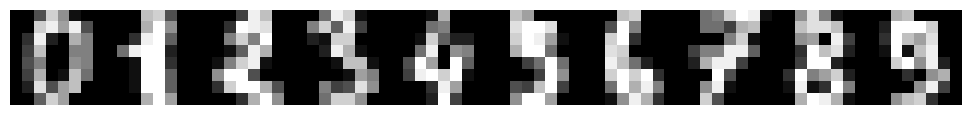

```python
# load the first two classes of the digits dataset
dataset = sklearn.datasets.load_digits()
digits_x, digits_y = dataset['data'], dataset['target']

# create a binary classification problem
digits_y = (digits_y < 5).astype(float)

# plot some of the digits
plt.figure(figsize=(10, 2))
plt.imshow(np.hstack([digits_x[i].reshape(8, 8) for i in range(10)]), cmap='gray')
plt.grid(False)
plt.tight_layout()
plt.axis('off')

# normalize the values to [0, 1]
digits_x -= np.mean(digits_x)
digits_x /= np.std(digits_x)

# print some statistics
print('digits_x.shape:', digits_x.shape)
print('digits_y.shape:', digits_y.shape)
print('min, max values:', np.min(digits_x), np.max(digits_x))
print('labels:', np.unique(digits_y))
```

We divide the dataset in a train and a test set.

```python
# make a 50%/50% train/test split
train_prop = 0.5
n_train = int(digits_x.shape[0] * train_prop)

# shuffle the images
rng = np.random.default_rng(12345)
idxs = rng.permutation(digits_x.shape[0])

# take a subset
x = {'train': digits_x[idxs[:n_train]],
     'test':  digits_x[idxs[n_train:]]}
y = {'train': digits_y[idxs[:n_train]],
     'test':  digits_y[idxs[n_train:]]}

print('Training samples:', x['train'].shape[0])
print('Test samples:', x['test'].shape[0])
```

```
Training samples: 898
Test samples: 899
```

We will now implement a function that trains the network. For each epoch, it loops over all minibatches in the training set and updates the network weights. It will then compute the loss and accuracy for the test samples. Finally, it will plot the learning curves.

**(a) Read through the code below.**

```python
def fit(net, x, y, epochs=25, learning_rate=0.001, mb_size=10):
    # initialize the loss and accuracy history
    loss_hist = {'train': [], 'test': []}
    accuracy_hist = {'train': [], 'test': []}

    for epoch in range(epochs):
        # initialize the loss and accuracy for this epoch
        loss = {'train': 0.0, 'test': 0.0}
        accuracy = {'train': 0.0, 'test': 0.0}

        # first train on training data, then evaluate on the test data
        for phase in ('train', 'test'):
            # compute the number of minibatches
            steps = x[phase].shape[0] // mb_size

            # loop over all minibatches
            for step in range(steps):
                # get the samples for the current minibatch
                x_mb = x[phase][(step * mb_size):((step + 1) * mb_size)]
                y_mb = y[phase][(step * mb_size):((step + 1) * mb_size), None]

                # compute the forward pass through the network
                pred_y, trace = net.forward(x_mb)

                # compute the current loss and accuracy
                loss[phase] += np.mean(bce_loss(y_mb, pred_y))
                accuracy[phase] += np.mean((y_mb > 0.5) == (pred_y > 0.5))

                # only update the network in the training phase
                if phase == 'train':
                    # compute the gradient for the loss
                    dy = bce_loss_grad(y_mb, pred_y)

                    # backpropagate the gradient through the network
                    net.backward(trace, dy)

                    # update the weights
                    net.step(learning_rate)

            # compute the mean loss and accuracy over all minibatches
            loss[phase] = loss[phase] / steps
            accuracy[phase] = accuracy[phase] / steps

            # add statistics to history
            loss_hist[phase].append(loss[phase])
            accuracy_hist[phase].append(accuracy[phase])

        print('Epoch %3d: loss[train]=%7.4f  accuracy[train]=%7.4f  loss[test]=%7.4f  accuracy[test]=%7.4f' %
              (epoch, loss['train'], accuracy['train'], loss['test'], accuracy['test']))

    # plot the learning curves
    plt.figure(figsize=(20, 5))

    plt.subplot(1, 2, 1)
    for phase in loss_hist:
        plt.plot(loss_hist[phase], label=phase)
    plt.title('BCE loss')
    plt.xlabel('Epoch')
    plt.legend()

    plt.subplot(1, 2, 2)
    for phase in accuracy_hist:
        plt.plot(accuracy_hist[phase], label=phase)
    plt.title('Accuracy')
    plt.xlabel('Epoch')
    plt.legend()
```

We will define a two-layer network:

- A linear layer that maps the 64 features of the input to 32 features.
- A ReLU activation function.
- A linear layer that maps the 32 features to the 1 output features.
- A sigmoid activation function that maps the output to [0, 1].

**1.6 b Add comment(b) Train the network and inspect the results. Tune the hyperparameters to get a good result. (1 point)**

*Grading:*

- 1 point if you choose a learning rate that converges to a good training and test accuracy.
- Training and test accuracy should be >= 0.96.

```
Epoch   0: loss[train]= 0.6947  accuracy[train]= 0.5000  loss[test]= 0.7011  accuracy[test]= 0.4697
Epoch   1: loss[train]= 0.6947  accuracy[train]= 0.5000  loss[test]= 0.7011  accuracy[test]= 0.4697
Epoch   2: loss[train]= 0.6947  accuracy[train]= 0.5000  loss[test]= 0.7011  accuracy[test]= 0.4697
Epoch   3: loss[train]= 0.6947  accuracy[train]= 0.5000  loss[test]= 0.7011  accuracy[test]= 0.4697
Epoch   4: loss[train]= 0.6947  accuracy[train]= 0.5000  loss[test]= 0.7011  accuracy[test]= 0.4697
Epoch   5: loss[train]= 0.6947  accuracy[train]= 0.5000  loss[test]= 0.7011  accuracy[test]= 0.4697
Epoch   6: loss[train]= 0.6947  accuracy[train]= 0.5000  loss[test]= 0.7011  accuracy[test]= 0.4697
Epoch   7: loss[train]= 0.6947  accuracy[train]= 0.5000  loss[test]= 0.7011  accuracy[test]= 0.4697
Epoch   8: loss[train]= 0.6947  accuracy[train]= 0.5000  loss[test]= 0.7011  accuracy[test]= 0.4697
Epoch   9: loss[train]= 0.6947  accuracy[train]= 0.5000  loss[test]= 0.7011  accuracy[test]= 0.4697
Epoch  10: loss[train]= 0.6947  accuracy[train]= 0.5000  loss[test]= 0.7011  accuracy[test]= 0.4697
Epoch  11: loss[train]= 0.6947  accuracy[train]= 0.5000  loss[test]= 0.7011  accuracy[test]= 0.4697
Epoch  12: loss[train]= 0.6947  accuracy[train]= 0.5000  loss[test]= 0.7011  accuracy[test]= 0.4697
Epoch  13: loss[train]= 0.6947  accuracy[train]= 0.5000  loss[test]= 0.7011  accuracy[test]= 0.4697
Epoch  14: loss[train]= 0.6947  accuracy[train]= 0.5000  loss[test]= 0.7011  accuracy[test]= 0.4697
Epoch  15: loss[train]= 0.6947  accuracy[train]= 0.5000  loss[test]= 0.7011  accuracy[test]= 0.4697
Epoch  16: loss[train]= 0.6947  accuracy[train]= 0.5000  loss[test]= 0.7011  accuracy[test]= 0.4697
Epoch  17: loss[train]= 0.6947  accuracy[train]= 0.5000  loss[test]= 0.7011  accuracy[test]= 0.4697
Epoch  18: loss[train]= 0.6947  accuracy[train]= 0.5000  loss[test]= 0.7011  accuracy[test]= 0.4697
Epoch  19: loss[train]= 0.6947  accuracy[train]= 0.5000  loss[test]= 0.7011  accuracy[test]= 0.4697
Epoch  20: loss[train]= 0.6947  accuracy[train]= 0.5000  loss[test]= 0.7011  accuracy[test]= 0.4697
Epoch  21: loss[train]= 0.6947  accuracy[train]= 0.5000  loss[test]= 0.7011  accuracy[test]= 0.4697
Epoch  22: loss[train]= 0.6947  accuracy[train]= 0.5000  loss[test]= 0.7011  accuracy[test]= 0.4697
Epoch  23: loss[train]= 0.6947  accuracy[train]= 0.5000  loss[test]= 0.7011  accuracy[test]= 0.4697
Epoch  24: loss[train]= 0.6947  accuracy[train]= 0.5000  loss[test]= 0.7011  accuracy[test]= 0.4697
Epoch   0: loss[train]= 0.4336  accuracy[train]= 0.8034  loss[test]= 0.2922  accuracy[test]= 0.8921
Epoch   1: loss[train]= 0.2477  accuracy[train]= 0.9146  loss[test]= 0.2061  accuracy[test]= 0.9281
Epoch   2: loss[train]= 0.1800  accuracy[train]= 0.9292  loss[test]= 0.1540  accuracy[test]= 0.9562
Epoch   3: loss[train]= 0.1376  accuracy[train]= 0.9461  loss[test]= 0.1250  accuracy[test]= 0.9640
Epoch   4: loss[train]= 0.1090  accuracy[train]= 0.9618  loss[test]= 0.1109  accuracy[test]= 0.9652
Epoch   5: loss[train]= 0.0890  accuracy[train]= 0.9730  loss[test]= 0.1012  accuracy[test]= 0.9674
Epoch   6: loss[train]= 0.0720  accuracy[train]= 0.9787  loss[test]= 0.0944  accuracy[test]= 0.9663
Epoch   7: loss[train]= 0.0605  accuracy[train]= 0.9865  loss[test]= 0.0902  accuracy[test]= 0.9674
Epoch   8: loss[train]= 0.0514  accuracy[train]= 0.9888  loss[test]= 0.0865  accuracy[test]= 0.9697
Epoch   9: loss[train]= 0.0447  accuracy[train]= 0.9899  loss[test]= 0.0836  accuracy[test]= 0.9708
Epoch  10: loss[train]= 0.0385  accuracy[train]= 0.9921  loss[test]= 0.0804  accuracy[test]= 0.9719
Epoch  11: loss[train]= 0.0336  accuracy[train]= 0.9933  loss[test]= 0.0779  accuracy[test]= 0.9730
Epoch  12: loss[train]= 0.0292  accuracy[train]= 0.9933  loss[test]= 0.0760  accuracy[test]= 0.9753
Epoch  13: loss[train]= 0.0251  accuracy[train]= 0.9944  loss[test]= 0.0739  accuracy[test]= 0.9764
Epoch  14: loss[train]= 0.0221  accuracy[train]= 0.9955  loss[test]= 0.0741  accuracy[test]= 0.9753
Epoch  15: loss[train]= 0.0194  accuracy[train]= 0.9978  loss[test]= 0.0722  accuracy[test]= 0.9764
Epoch  16: loss[train]= 0.0171  accuracy[train]= 0.9978  loss[test]= 0.0718  accuracy[test]= 0.9764
Epoch  17: loss[train]= 0.0150  accuracy[train]= 0.9989  loss[test]= 0.0713  accuracy[test]= 0.9764
Epoch  18: loss[train]= 0.0135  accuracy[train]= 0.9989  loss[test]= 0.0702  accuracy[test]= 0.9775
Epoch  19: loss[train]= 0.0120  accuracy[train]= 1.0000  loss[test]= 0.0707  accuracy[test]= 0.9775
Epoch  20: loss[train]= 0.0109  accuracy[train]= 1.0000  loss[test]= 0.0690  accuracy[test]= 0.9775
Epoch  21: loss[train]= 0.0099  accuracy[train]= 1.0000  loss[test]= 0.0689  accuracy[test]= 0.9775
Epoch  22: loss[train]= 0.0090  accuracy[train]= 1.0000  loss[test]= 0.0690  accuracy[test]= 0.9775
Epoch  23: loss[train]= 0.0083  accuracy[train]= 1.0000  loss[test]= 0.0685  accuracy[test]= 0.9775
Epoch  24: loss[train]= 0.0076  accuracy[train]= 1.0000  loss[test]= 0.0683  accuracy[test]= 0.9775
```

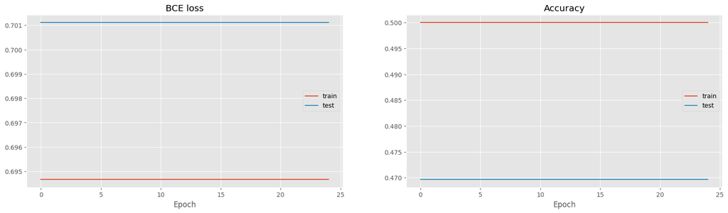

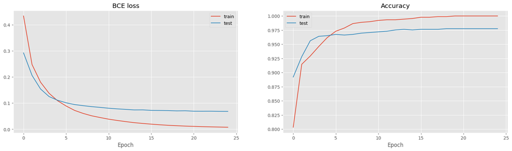

```python
### BEGIN ANSWER
# construct network
net = Net([
        Linear(64, 32, rng=rng),
        ReLU(),
        Linear(32, 1, rng=rng),
        Sigmoid()])

# train the network
fit(net, x, y,
    epochs = 25,
    learning_rate = 0.01,
    mb_size = 10)
### END ANSWER
```

**1.6 c Add comment(c) How did each of the hyperparameters (number of epochs, learning rate, minibatch size) influence your results? How important is it to set each correctly? (3 points)**

Answer

- It is important to set the number of epochs large enough. The model takes some time to reach a good performance.
- The learning rate must not be too small, which would slow down training, but also not too large, because that causes instabilities.
- The minibatch size is less important, as long as it is large enough.

*Grading:*

- 1 point for each of the three hyperparameters.

**1.6 d Add comment(d) Create and train a network with one linear layer followed by a sigmoid activation: (1 point)**

`net = Net([Linear(...), Sigmoid()]`

*Grading:*

- 1 point for a correct implementation, trained with good hyperparameters.

```
Epoch   0: loss[train]= 0.4806  accuracy[train]= 0.7708  loss[test]= 0.3638  accuracy[test]= 0.8652
Epoch   1: loss[train]= 0.3385  accuracy[train]= 0.8719  loss[test]= 0.3278  accuracy[test]= 0.8798
Epoch   2: loss[train]= 0.3122  accuracy[train]= 0.8764  loss[test]= 0.3117  accuracy[test]= 0.8843
Epoch   3: loss[train]= 0.2988  accuracy[train]= 0.8831  loss[test]= 0.3023  accuracy[test]= 0.8865
Epoch   4: loss[train]= 0.2906  accuracy[train]= 0.8876  loss[test]= 0.2963  accuracy[test]= 0.8865
Epoch   5: loss[train]= 0.2851  accuracy[train]= 0.8899  loss[test]= 0.2923  accuracy[test]= 0.8876
Epoch   6: loss[train]= 0.2812  accuracy[train]= 0.8910  loss[test]= 0.2894  accuracy[test]= 0.8888
Epoch   7: loss[train]= 0.2783  accuracy[train]= 0.8955  loss[test]= 0.2874  accuracy[test]= 0.8910
Epoch   8: loss[train]= 0.2761  accuracy[train]= 0.8933  loss[test]= 0.2858  accuracy[test]= 0.8910
Epoch   9: loss[train]= 0.2744  accuracy[train]= 0.8899  loss[test]= 0.2847  accuracy[test]= 0.8910
Epoch  10: loss[train]= 0.2730  accuracy[train]= 0.8910  loss[test]= 0.2839  accuracy[test]= 0.8921
Epoch  11: loss[train]= 0.2719  accuracy[train]= 0.8921  loss[test]= 0.2833  accuracy[test]= 0.8933
Epoch  12: loss[train]= 0.2709  accuracy[train]= 0.8933  loss[test]= 0.2828  accuracy[test]= 0.8944
Epoch  13: loss[train]= 0.2701  accuracy[train]= 0.8921  loss[test]= 0.2825  accuracy[test]= 0.8944
Epoch  14: loss[train]= 0.2695  accuracy[train]= 0.8944  loss[test]= 0.2823  accuracy[test]= 0.8933
Epoch  15: loss[train]= 0.2689  accuracy[train]= 0.8944  loss[test]= 0.2822  accuracy[test]= 0.8933
Epoch  16: loss[train]= 0.2684  accuracy[train]= 0.8944  loss[test]= 0.2821  accuracy[test]= 0.8955
Epoch  17: loss[train]= 0.2680  accuracy[train]= 0.8933  loss[test]= 0.2821  accuracy[test]= 0.8966
Epoch  18: loss[train]= 0.2676  accuracy[train]= 0.8933  loss[test]= 0.2821  accuracy[test]= 0.8966
Epoch  19: loss[train]= 0.2672  accuracy[train]= 0.8944  loss[test]= 0.2822  accuracy[test]= 0.8966
Epoch  20: loss[train]= 0.2669  accuracy[train]= 0.8944  loss[test]= 0.2823  accuracy[test]= 0.8978
Epoch  21: loss[train]= 0.2666  accuracy[train]= 0.8944  loss[test]= 0.2824  accuracy[test]= 0.8989
Epoch  22: loss[train]= 0.2664  accuracy[train]= 0.8944  loss[test]= 0.2825  accuracy[test]= 0.8989
Epoch  23: loss[train]= 0.2661  accuracy[train]= 0.8944  loss[test]= 0.2827  accuracy[test]= 0.9000
Epoch  24: loss[train]= 0.2659  accuracy[train]= 0.8944  loss[test]= 0.2828  accuracy[test]= 0.9000
Epoch  25: loss[train]= 0.2657  accuracy[train]= 0.8933  loss[test]= 0.2830  accuracy[test]= 0.8989
Epoch  26: loss[train]= 0.2655  accuracy[train]= 0.8910  loss[test]= 0.2832  accuracy[test]= 0.8989
Epoch  27: loss[train]= 0.2653  accuracy[train]= 0.8899  loss[test]= 0.2833  accuracy[test]= 0.8989
Epoch  28: loss[train]= 0.2652  accuracy[train]= 0.8921  loss[test]= 0.2835  accuracy[test]= 0.8989
Epoch  29: loss[train]= 0.2650  accuracy[train]= 0.8910  loss[test]= 0.2837  accuracy[test]= 0.8989
Epoch  30: loss[train]= 0.2649  accuracy[train]= 0.8910  loss[test]= 0.2839  accuracy[test]= 0.8989
Epoch  31: loss[train]= 0.2647  accuracy[train]= 0.8910  loss[test]= 0.2841  accuracy[test]= 0.8989
Epoch  32: loss[train]= 0.2646  accuracy[train]= 0.8910  loss[test]= 0.2843  accuracy[test]= 0.8989
Epoch  33: loss[train]= 0.2645  accuracy[train]= 0.8910  loss[test]= 0.2845  accuracy[test]= 0.8989
Epoch  34: loss[train]= 0.2644  accuracy[train]= 0.8910  loss[test]= 0.2847  accuracy[test]= 0.8989
Epoch  35: loss[train]= 0.2643  accuracy[train]= 0.8910  loss[test]= 0.2848  accuracy[test]= 0.8989
Epoch  36: loss[train]= 0.2642  accuracy[train]= 0.8910  loss[test]= 0.2850  accuracy[test]= 0.8989
Epoch  37: loss[train]= 0.2641  accuracy[train]= 0.8910  loss[test]= 0.2852  accuracy[test]= 0.8989
Epoch  38: loss[train]= 0.2640  accuracy[train]= 0.8910  loss[test]= 0.2854  accuracy[test]= 0.9000
Epoch  39: loss[train]= 0.2639  accuracy[train]= 0.8910  loss[test]= 0.2856  accuracy[test]= 0.9000
Epoch  40: loss[train]= 0.2638  accuracy[train]= 0.8910  loss[test]= 0.2857  accuracy[test]= 0.9000
Epoch  41: loss[train]= 0.2637  accuracy[train]= 0.8910  loss[test]= 0.2859  accuracy[test]= 0.9000
Epoch  42: loss[train]= 0.2636  accuracy[train]= 0.8910  loss[test]= 0.2861  accuracy[test]= 0.9000
Epoch  43: loss[train]= 0.2635  accuracy[train]= 0.8910  loss[test]= 0.2862  accuracy[test]= 0.9011
Epoch  44: loss[train]= 0.2635  accuracy[train]= 0.8899  loss[test]= 0.2864  accuracy[test]= 0.9011
Epoch  45: loss[train]= 0.2634  accuracy[train]= 0.8888  loss[test]= 0.2866  accuracy[test]= 0.9011
Epoch  46: loss[train]= 0.2633  accuracy[train]= 0.8876  loss[test]= 0.2867  accuracy[test]= 0.9011
Epoch  47: loss[train]= 0.2632  accuracy[train]= 0.8876  loss[test]= 0.2869  accuracy[test]= 0.9000
Epoch  48: loss[train]= 0.2632  accuracy[train]= 0.8876  loss[test]= 0.2870  accuracy[test]= 0.8989
Epoch  49: loss[train]= 0.2631  accuracy[train]= 0.8876  loss[test]= 0.2872  accuracy[test]= 0.8989
```

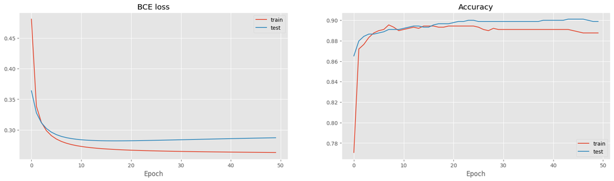

```python
### BEGIN ANSWER
rng = np.random.default_rng(12345)
net = Net([
        Linear(64, 1, rng),
        Sigmoid()])

# train the network
fit(net, x, y,
    epochs = 50,
    learning_rate = 0.01,
    mb_size = 10)
### END ANSWER
```

**1.6 e Add comment(e) Discuss your results. Compare the results of this single-layer network with those of the network you trained before. (1 point)**

Answer: The test accuracy of the network with a single linear layer is lower than that of the previous, more complex network with two linear layers. The additional layer allows the model to make better predictions.

For the shallow network, the difference between the train and test accuracy is smaller than for the deeper network. The deeper network is overfitting slightly to the training set, because it is more complex. (But the performance on the test set is also improved, so the overfitting is not too harmful.)

*Grading:*

- 0.5 point for correctly comparing test performance with more complex network.
- plus 0.5 point for also discussing training performance or discussing under-/overfitting.

**1.6 f Add comment(f) Repeat the experiment with a network with two linear layers, followed by a sigmoid activation: `[Linear, Linear, Sigmoid]`. (1 point)**

*Grading:*

- 1 point for a correct implementation, trained with good hyperparameters.

```
Epoch   0: loss[train]= 0.4407  accuracy[train]= 0.7921  loss[test]= 0.3392  accuracy[test]= 0.8685
Epoch   1: loss[train]= 0.3315  accuracy[train]= 0.8674  loss[test]= 0.3100  accuracy[test]= 0.8764
Epoch   2: loss[train]= 0.3122  accuracy[train]= 0.8787  loss[test]= 0.2992  accuracy[test]= 0.8798
Epoch   3: loss[train]= 0.3023  accuracy[train]= 0.8764  loss[test]= 0.2941  accuracy[test]= 0.8831
Epoch   4: loss[train]= 0.2960  accuracy[train]= 0.8787  loss[test]= 0.2915  accuracy[test]= 0.8876
Epoch   5: loss[train]= 0.2913  accuracy[train]= 0.8809  loss[test]= 0.2900  accuracy[test]= 0.8865
Epoch   6: loss[train]= 0.2878  accuracy[train]= 0.8809  loss[test]= 0.2890  accuracy[test]= 0.8865
Epoch   7: loss[train]= 0.2850  accuracy[train]= 0.8843  loss[test]= 0.2883  accuracy[test]= 0.8865
Epoch   8: loss[train]= 0.2826  accuracy[train]= 0.8865  loss[test]= 0.2878  accuracy[test]= 0.8910
Epoch   9: loss[train]= 0.2807  accuracy[train]= 0.8876  loss[test]= 0.2873  accuracy[test]= 0.8921
Epoch  10: loss[train]= 0.2790  accuracy[train]= 0.8888  loss[test]= 0.2869  accuracy[test]= 0.8921
Epoch  11: loss[train]= 0.2776  accuracy[train]= 0.8888  loss[test]= 0.2866  accuracy[test]= 0.8921
Epoch  12: loss[train]= 0.2763  accuracy[train]= 0.8876  loss[test]= 0.2863  accuracy[test]= 0.8933
Epoch  13: loss[train]= 0.2752  accuracy[train]= 0.8899  loss[test]= 0.2860  accuracy[test]= 0.8944
Epoch  14: loss[train]= 0.2742  accuracy[train]= 0.8899  loss[test]= 0.2858  accuracy[test]= 0.8955
Epoch  15: loss[train]= 0.2733  accuracy[train]= 0.8910  loss[test]= 0.2855  accuracy[test]= 0.8966
Epoch  16: loss[train]= 0.2725  accuracy[train]= 0.8910  loss[test]= 0.2853  accuracy[test]= 0.8966
Epoch  17: loss[train]= 0.2717  accuracy[train]= 0.8910  loss[test]= 0.2851  accuracy[test]= 0.8978
Epoch  18: loss[train]= 0.2710  accuracy[train]= 0.8921  loss[test]= 0.2849  accuracy[test]= 0.8989
Epoch  19: loss[train]= 0.2704  accuracy[train]= 0.8933  loss[test]= 0.2847  accuracy[test]= 0.9000
Epoch  20: loss[train]= 0.2698  accuracy[train]= 0.8944  loss[test]= 0.2845  accuracy[test]= 0.9000
Epoch  21: loss[train]= 0.2693  accuracy[train]= 0.8944  loss[test]= 0.2844  accuracy[test]= 0.9000
Epoch  22: loss[train]= 0.2688  accuracy[train]= 0.8944  loss[test]= 0.2842  accuracy[test]= 0.8989
Epoch  23: loss[train]= 0.2683  accuracy[train]= 0.8955  loss[test]= 0.2841  accuracy[test]= 0.9000
Epoch  24: loss[train]= 0.2679  accuracy[train]= 0.8944  loss[test]= 0.2839  accuracy[test]= 0.9011
Epoch  25: loss[train]= 0.2674  accuracy[train]= 0.8944  loss[test]= 0.2838  accuracy[test]= 0.9022
Epoch  26: loss[train]= 0.2671  accuracy[train]= 0.8944  loss[test]= 0.2837  accuracy[test]= 0.9022
Epoch  27: loss[train]= 0.2667  accuracy[train]= 0.8944  loss[test]= 0.2835  accuracy[test]= 0.9022
Epoch  28: loss[train]= 0.2663  accuracy[train]= 0.8933  loss[test]= 0.2834  accuracy[test]= 0.9022
Epoch  29: loss[train]= 0.2660  accuracy[train]= 0.8933  loss[test]= 0.2833  accuracy[test]= 0.9022
Epoch  30: loss[train]= 0.2657  accuracy[train]= 0.8933  loss[test]= 0.2832  accuracy[test]= 0.9022
Epoch  31: loss[train]= 0.2654  accuracy[train]= 0.8921  loss[test]= 0.2831  accuracy[test]= 0.9022
Epoch  32: loss[train]= 0.2651  accuracy[train]= 0.8921  loss[test]= 0.2830  accuracy[test]= 0.9022
Epoch  33: loss[train]= 0.2648  accuracy[train]= 0.8910  loss[test]= 0.2829  accuracy[test]= 0.9022
Epoch  34: loss[train]= 0.2645  accuracy[train]= 0.8910  loss[test]= 0.2828  accuracy[test]= 0.9022
Epoch  35: loss[train]= 0.2643  accuracy[train]= 0.8910  loss[test]= 0.2828  accuracy[test]= 0.9022
Epoch  36: loss[train]= 0.2641  accuracy[train]= 0.8910  loss[test]= 0.2827  accuracy[test]= 0.9022
Epoch  37: loss[train]= 0.2638  accuracy[train]= 0.8910  loss[test]= 0.2826  accuracy[test]= 0.9022
Epoch  38: loss[train]= 0.2636  accuracy[train]= 0.8910  loss[test]= 0.2825  accuracy[test]= 0.9022
Epoch  39: loss[train]= 0.2634  accuracy[train]= 0.8910  loss[test]= 0.2825  accuracy[test]= 0.9034
Epoch  40: loss[train]= 0.2632  accuracy[train]= 0.8910  loss[test]= 0.2824  accuracy[test]= 0.9034
Epoch  41: loss[train]= 0.2630  accuracy[train]= 0.8921  loss[test]= 0.2823  accuracy[test]= 0.9034
Epoch  42: loss[train]= 0.2628  accuracy[train]= 0.8921  loss[test]= 0.2823  accuracy[test]= 0.9034
Epoch  43: loss[train]= 0.2626  accuracy[train]= 0.8921  loss[test]= 0.2822  accuracy[test]= 0.9034
Epoch  44: loss[train]= 0.2624  accuracy[train]= 0.8921  loss[test]= 0.2822  accuracy[test]= 0.9034
Epoch  45: loss[train]= 0.2622  accuracy[train]= 0.8921  loss[test]= 0.2821  accuracy[test]= 0.9034
Epoch  46: loss[train]= 0.2621  accuracy[train]= 0.8921  loss[test]= 0.2821  accuracy[test]= 0.9034
Epoch  47: loss[train]= 0.2619  accuracy[train]= 0.8910  loss[test]= 0.2820  accuracy[test]= 0.9045
Epoch  48: loss[train]= 0.2618  accuracy[train]= 0.8921  loss[test]= 0.2820  accuracy[test]= 0.9045
Epoch  49: loss[train]= 0.2616  accuracy[train]= 0.8921  loss[test]= 0.2819  accuracy[test]= 0.9034
```

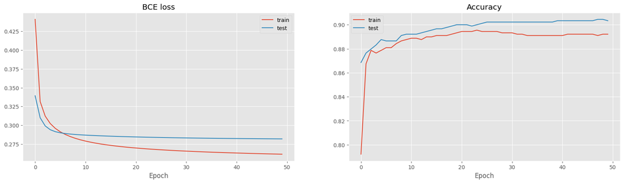

```python
### BEGIN ANSWER
rng = np.random.default_rng(12345)
net = Net([
        Linear(64, 32, rng=rng),
        Linear(32, 1, rng=rng),
        Sigmoid()])

# train the network
fit(net, x, y,
    epochs = 50,
    learning_rate = 0.01,
    mb_size = 10)
### END ANSWER
```

**1.6 g Add comment(g) How does the performance of this network compare with the previous networks. Can you explain this result? What is the influence of the activation functions in the network? (1 point)**

Answer: The performance of a network with two linear layers without a ReLU in between is the same as that of a network with a single linear layer. Two linear layers without a nonlinearity in between can be combined into a single linear layer:

The network \begin{align} H_1 &= X W_1 + b_1 \\ H_2 &= H_1 W_2 + b_2 \end{align} can be rewritten as \begin{align} H_2 &= (X W_1 + b_1) W_2 + b_2 \\ &= X W_1 W_2 + (b_1 W_2 + b_2) \\ &= X W_{combined} + b_{combined} \end{align} with \begin{align} W_{combined} &= W_1 W_2 & b_{combined} = b_1 W_2 + b_2 \end{align}

Note that in practice the results can be slightly different, because the a two layer model still has more parameters, and the effective learning rate for $W_{combined}$ is different.

The activation function (such as a ReLU or sigmoid) adds a nonlinear transformation, which means that the two layers can no longer be collapsed into one. This allows the model to learn more complex functions.

*Grading:*

- 1 point for a correct argument that discusses why you need an activation function between two linear layers. Either saying that the result is still linear, or by comparing the performance to a single layer network. (The mathematical derivation is not required.)
- 0.5 point for only observing that the network without non-linearities is worse.

**1.6 h Add comment(h) One way to improve the performance of a neural network is by increasing the number of layers. Try a deeper network (e.g., a network with four linear layers) to see if this outperforms the previous networks. (1 point)**

*Grading:*

- 1 point for a correct implementation, trained with good hyperparameters.
- No points for a network with linear layers without activation functions in between.

```
Epoch   0: loss[train]= 0.6925  accuracy[train]= 0.5281  loss[test]= 0.6882  accuracy[test]= 0.4955
Epoch   1: loss[train]= 0.6379  accuracy[train]= 0.7112  loss[test]= 0.4687  accuracy[test]= 0.8539
Epoch   2: loss[train]= 0.3707  accuracy[train]= 0.8551  loss[test]= 0.2548  accuracy[test]= 0.9101
Epoch   3: loss[train]= 0.2201  accuracy[train]= 0.9191  loss[test]= 0.1634  accuracy[test]= 0.9371
Epoch   4: loss[train]= 0.1517  accuracy[train]= 0.9416  loss[test]= 0.1084  accuracy[test]= 0.9652
Epoch   5: loss[train]= 0.1095  accuracy[train]= 0.9551  loss[test]= 0.1092  accuracy[test]= 0.9596
Epoch   6: loss[train]= 0.0676  accuracy[train]= 0.9775  loss[test]= 0.1109  accuracy[test]= 0.9618
Epoch   7: loss[train]= 0.0612  accuracy[train]= 0.9764  loss[test]= 0.0750  accuracy[test]= 0.9753
Epoch   8: loss[train]= 0.0666  accuracy[train]= 0.9809  loss[test]= 0.0867  accuracy[test]= 0.9708
Epoch   9: loss[train]= 0.0410  accuracy[train]= 0.9865  loss[test]= 0.1002  accuracy[test]= 0.9663
Epoch  10: loss[train]= 0.0238  accuracy[train]= 0.9944  loss[test]= 0.0645  accuracy[test]= 0.9764
Epoch  11: loss[train]= 0.0190  accuracy[train]= 0.9944  loss[test]= 0.0619  accuracy[test]= 0.9753
Epoch  12: loss[train]= 0.0086  accuracy[train]= 0.9989  loss[test]= 0.0704  accuracy[test]= 0.9753
Epoch  13: loss[train]= 0.0057  accuracy[train]= 0.9989  loss[test]= 0.0688  accuracy[test]= 0.9764
Epoch  14: loss[train]= 0.0035  accuracy[train]= 0.9989  loss[test]= 0.0697  accuracy[test]= 0.9764
Epoch  15: loss[train]= 0.0020  accuracy[train]= 1.0000  loss[test]= 0.0811  accuracy[test]= 0.9775
Epoch  16: loss[train]= 0.0013  accuracy[train]= 1.0000  loss[test]= 0.0780  accuracy[test]= 0.9775
Epoch  17: loss[train]= 0.0010  accuracy[train]= 1.0000  loss[test]= 0.0754  accuracy[test]= 0.9775
Epoch  18: loss[train]= 0.0008  accuracy[train]= 1.0000  loss[test]= 0.0768  accuracy[test]= 0.9787
Epoch  19: loss[train]= 0.0007  accuracy[train]= 1.0000  loss[test]= 0.0773  accuracy[test]= 0.9787
Epoch  20: loss[train]= 0.0006  accuracy[train]= 1.0000  loss[test]= 0.0780  accuracy[test]= 0.9787
Epoch  21: loss[train]= 0.0005  accuracy[train]= 1.0000  loss[test]= 0.0778  accuracy[test]= 0.9787
Epoch  22: loss[train]= 0.0005  accuracy[train]= 1.0000  loss[test]= 0.0793  accuracy[test]= 0.9787
Epoch  23: loss[train]= 0.0004  accuracy[train]= 1.0000  loss[test]= 0.0796  accuracy[test]= 0.9787
Epoch  24: loss[train]= 0.0004  accuracy[train]= 1.0000  loss[test]= 0.0801  accuracy[test]= 0.9787
Epoch  25: loss[train]= 0.0003  accuracy[train]= 1.0000  loss[test]= 0.0814  accuracy[test]= 0.9787
Epoch  26: loss[train]= 0.0003  accuracy[train]= 1.0000  loss[test]= 0.0815  accuracy[test]= 0.9775
Epoch  27: loss[train]= 0.0003  accuracy[train]= 1.0000  loss[test]= 0.0819  accuracy[test]= 0.9787
Epoch  28: loss[train]= 0.0003  accuracy[train]= 1.0000  loss[test]= 0.0830  accuracy[test]= 0.9787
Epoch  29: loss[train]= 0.0003  accuracy[train]= 1.0000  loss[test]= 0.0832  accuracy[test]= 0.9775
Epoch  30: loss[train]= 0.0002  accuracy[train]= 1.0000  loss[test]= 0.0836  accuracy[test]= 0.9787
Epoch  31: loss[train]= 0.0002  accuracy[train]= 1.0000  loss[test]= 0.0841  accuracy[test]= 0.9775
Epoch  32: loss[train]= 0.0002  accuracy[train]= 1.0000  loss[test]= 0.0850  accuracy[test]= 0.9787
Epoch  33: loss[train]= 0.0002  accuracy[train]= 1.0000  loss[test]= 0.0846  accuracy[test]= 0.9775
Epoch  34: loss[train]= 0.0002  accuracy[train]= 1.0000  loss[test]= 0.0856  accuracy[test]= 0.9787
Epoch  35: loss[train]= 0.0002  accuracy[train]= 1.0000  loss[test]= 0.0861  accuracy[test]= 0.9787
Epoch  36: loss[train]= 0.0002  accuracy[train]= 1.0000  loss[test]= 0.0858  accuracy[test]= 0.9787
Epoch  37: loss[train]= 0.0002  accuracy[train]= 1.0000  loss[test]= 0.0867  accuracy[test]= 0.9787
Epoch  38: loss[train]= 0.0002  accuracy[train]= 1.0000  loss[test]= 0.0873  accuracy[test]= 0.9787
Epoch  39: loss[train]= 0.0001  accuracy[train]= 1.0000  loss[test]= 0.0873  accuracy[test]= 0.9787
Epoch  40: loss[train]= 0.0001  accuracy[train]= 1.0000  loss[test]= 0.0875  accuracy[test]= 0.9787
Epoch  41: loss[train]= 0.0001  accuracy[train]= 1.0000  loss[test]= 0.0880  accuracy[test]= 0.9787
Epoch  42: loss[train]= 0.0001  accuracy[train]= 1.0000  loss[test]= 0.0881  accuracy[test]= 0.9787
Epoch  43: loss[train]= 0.0001  accuracy[train]= 1.0000  loss[test]= 0.0888  accuracy[test]= 0.9787
Epoch  44: loss[train]= 0.0001  accuracy[train]= 1.0000  loss[test]= 0.0887  accuracy[test]= 0.9787
Epoch  45: loss[train]= 0.0001  accuracy[train]= 1.0000  loss[test]= 0.0893  accuracy[test]= 0.9787
Epoch  46: loss[train]= 0.0001  accuracy[train]= 1.0000  loss[test]= 0.0895  accuracy[test]= 0.9787
Epoch  47: loss[train]= 0.0001  accuracy[train]= 1.0000  loss[test]= 0.0896  accuracy[test]= 0.9787
Epoch  48: loss[train]= 0.0001  accuracy[train]= 1.0000  loss[test]= 0.0903  accuracy[test]= 0.9787
Epoch  49: loss[train]= 0.0001  accuracy[train]= 1.0000  loss[test]= 0.0903  accuracy[test]= 0.9787
```

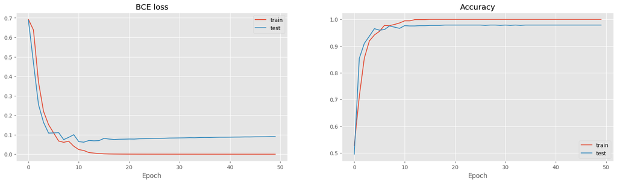

```python
### BEGIN ANSWER
rng = np.random.default_rng(12345)
net = Net([
        Linear(64, 64, rng=rng),
        ReLU(),
        Linear(64, 64, rng=rng),
        ReLU(),
        Linear(64, 32, rng=rng),
        ReLU(),
        Linear(32, 1, rng=rng),
        Sigmoid()])

# train the network
fit(net, x, y,
    epochs = 50,
    learning_rate = 0.01,
    mb_size = 10)
### END ANSWER
```

**1.6 i Add comment(i) Discuss your findings. Were you able to obtain a perfect classification? Explain the learning curves. (1 point)**

Answer: This more complex model performs better than the simpler models. However, it is not possible to get a perfect classification on the test set. The near-perfect accuracy on the training set is due to overfitting.

*Grading:*

- 0.5 point for comparing simple and complex models.
- plus 0.5 point for an answer that mentions the imperfect results on the test set.

## 1.7 Final questions (6 points)

You now have some experience training neural networks. Time for a few final questions.

**1.7 a Add comment(a) What is the influence of the learning rate? What happens if the learning rate is too low or too high? (2 points)**

Answer:

The learning rate determines the size of the gradient descent updates. If the learning rate is too low, the model learns slowly and might get stuck in a local optimum. If the learning rate is too high, the update steps may be too large to optimize the model precisely. The large updates can also introduce numerical problems.

*Grading:*

- 2 points for a correct argument that discusses both low and high learning rates.
- Max. 1 point if only one is discussed.

**1.7 b Add comment(b) What is the role of the minibatch size in SGD? Explain the downsides of a minibatch size that is too small or too high. (2 points)**

Answer:

The minibatch size has an effect on the quality of the gradient estimates.

- If the minibatch is very small, the estimated gradient will not be close to the true gradient, which makes it more difficult to optimize the model.
- On the other hand, a very large minibatch size is inefficient: it provides high-quality gradient estimates, but each update step requires much more computations.
- *(Optional, not required for points.)* For very large models, there may also be a practical limit to the minibatch size, because the available GPU memory is limited.
- *(Optional, not required for points.)* The noise from small minibatches might help the optimizer to escape local minima, and have a regularizing effect.

*Grading:*

- 2 point for a correct argument that discusses both small and large minibatch sizes.
- Max. 1 point if only one is discussed.

**1.7 c Add comment(c) In the linear layer, we initialized the weights $w$ with random values, but we initialized the bias $b$ with zeros. What would happen if the weights $w$ were initialised as zeros? Why is this not a problem for the bias? (2 points)**

Answer:

If all weights $w$ are initialised as zeros, the output of the model would be zero as well. Moreover, it will be impossible for the model to move away from this, since the gradients also depend on $w$: the updates would be zero as well. It is much better to initialise the weights to random values. Another way of looking at this is by noting that if all the weights of two neurons are the same, then their outputs will also always be the same, and so will the gradients. It is impossible to break this symmetry with gradient based optimization. Using (small) random weights can break this symmetry.

For the bias $b$, initialising to zero is not a problem, because they are not used as multiplication terms in the backpropagated gradients. (In fact, biases are usually initialised to 0 in most applications.) Symmetry of the neurons is also not a problem with identical biases, as long as the neurons' weights are different.

*Grading:*

- 1 point for a correct argument about the weights (either about zero outputs or identical neurons),
- 1 point for a correct argument about the bias.
- Either an argument about the output being zero or about symmetry between neurons is okay.

## The end

Well done! Please double check the instructions at the top before you submit your results.

*This assignment has 45 points.* Version 00f98aa / 2023-09-04

## Score form

Something didn't work. Save the following list of scores in a text file and upload to Brightspace:

Download the scores as a text file